# TALLER 1: CRÍTICA VISUALIZACIÓN DE DATOS

## *Visualización uno*

### How Britain Voted

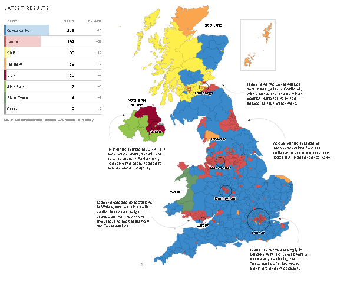

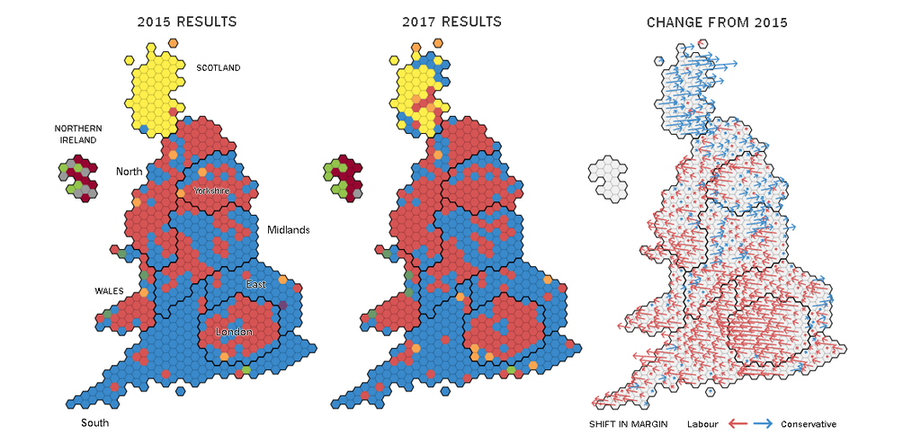

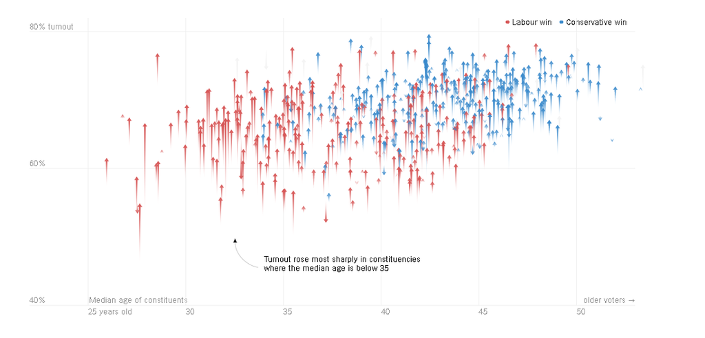

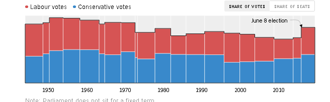

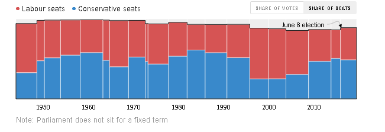

#### Está visualización nos muestra como se comporto las elecciones y el numero de asientos obtenidos y el cambió frente a las elecciones 2015 donde el partido conservador tenía la mayoría

1. $¿qué?$, $¿por qué?$ y $¿cómo?$
- $¿qué?$

Los datos que se quieren mostrar son el comportamiento de los votantes en el Reuino Unido en el año 2017 de las elecciones parlamentarias, en esto sabemos que tenemos la base de datos con datos categoricos ordenados (ubicación geográfica) y tenemos el número de votos obtenidos por el partido ganador en esa ubicación.

- $¿porqué?$

En particular se quiere visualizar el comportamiento geográfico al menos en esta primera visualización, ya que en esta visualización observamos en que lugares del país tuvo mayoría de votos un partido especifico, está visualización busca presentar como se distribuyeron los votos dentro del territorio del Reino Unido. Adicional a esto se quiere mostrar el cambio entre las elecciones 2015 y 2017

- $¿cómo?$

No se puede apreciar en la imagen, pero si nos remitimos a https://www.nytimes.com/interactive/2017/06/08/world/europe/british-general-election-results-analysis.html donde se encuentra completa la visualización podemos observar que cuenta con una interacción sencilla en la cual si nos paramos sobre algún punto nos desgloza el nombre y el porcentaje de votos obtenidos por cada partido en esa zona especifica del total de votos en ese mismo lugar, esto ocurre para las primeras 3 visualizaciones, mientras que para las últimas dos al pararse sobre una barra se despliega información del año, y la representación porcentual que tuvo de votos cada partido en ese año particular.

1. Marcas y canales utilizados
- Marcas: La marca utilizada en este caso es el area geográfica y las flechas.
- Canal: El canal para está visualización es el color, el cual nos permite distinguir de un area geográfica a otra que partido fue el que obtivo más votos, además del canal de posición.
1. Cumple o no cumple alguna de las reglas generales descritas

Cumple, no utiliza inecesariamente recursos, adicional a que utiliza la navegación dentro de una sola vista para poder comparar zonas geográficas y si queremos ver el detalle de alguna ubicación en especifico basta con poner el cursor sobre está para que la información se despliegue.

1. Mejoras posibles, en cuánto a marcas o canales, que le realizaría a la visualización

En mi opinión está visualización cuando usa el canal de las flechas pierde claridad, adicional a que en ocaciones están muy cercas entre ellas, lo que hace que a simple vista sea dificil de sacar conclusiones de está, cuando las flechas en el mapa alcanza a ser comprensible aunque no me parezca la mejor manera de mostrarlo, sin embargo en la imagen siguiente en lo personal no me queda claro que se quiere mostrar con está.

## Fuente

The New York Times, *How Britain Voted*, G. AISCH, M. BLOCH, K. DAVIS, S. FARRELL, T. GRIGGS, R. HARRIS and A. PEARCE, recuperado de https://www.nytimes.com/interactive/2017/06/08/world/europe/british-general-election-results-analysis.html el 23 de febrero de 2021

## *Visualización dos*

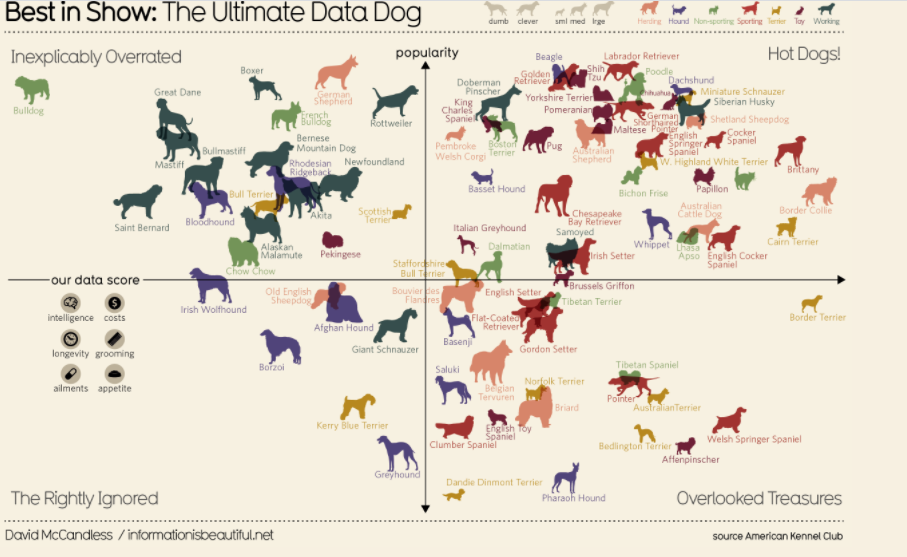

- $¿porqué?$

Lo que se puede pensar es que se busco mostrar de manera gráfica donde se ubicaba cada raza de perro, se puede pensar en clasificar está visualización como enjoy y organiza las razas según sus atributos de popularidad e inteligencia, costo, longevidad, cuidado higienico, alimentos y apetito.

- $¿cómo?$

Utiliza una codificación visual Separate.

1. Marcas y canales utilizados
- Marcas: La marca utilizada en este caso son puntos.
- Canal: El canal para está visualización es el color, la forma que le da a cada punto con la silueta de la raza de perro y la dirección a la que la silueta observa.
1. Cumple o no cumple alguna de las reglas generales descritas

A mi modo de ver rompe la regla del 2D injustificado, ya que por la forma en que se presenta la visualización aún en 2D se presentan problemas que son tipicos del 3D como la oclusión.

1. Mejoras posibles, en cuánto a marcas o canales, que le realizaría a la visualización

Sería preferible realizar un cambio en las formas puesto que por los tamaños secubren unos con otros, además el canal de dirección en la que la silueta no aporta información facilmente perceptible ya que la visualización es tan cargada que el ojo a simple vista no logra distinguir ni el nombre de la raza ni cuales ven a que dirección. Adicional a todo lo anterior los colores no ayudan, haciendo que está visualización sea agotadora de ver, en esté caso sería preferible tener una lista de las razas y al clickear sobre está se muestre en donde se ubica y una leyenda que aclare esa ubicación que significa, puesto que esto no es claro.